# Netværksgraf

baj

# Netværk

Opdel alle på titel, akt og scene. Vi vil gerne nå frem til en grafisk fremstilling af netværk.

5. Find karakterer med replikker, der taler med hinanden – hele stykket.
   1. Graduer efter, hvor mange ord, de siger til hinanden.
   2. Talende karakter: det skal visuelt fremgå, dvs hvem der taler mest.
6. Find karakterer, der taler med hinanden – opdelt i akt og scene.
   1. Graduer efter, hvor mange ord, de siger til hinanden.

Jf Frank Fischer – “taler med hinanden” defineres som karakterer, der taler i en scene. Moretti – definerer ift karakterer, der taler efter hinanden. Vi starter med Fischer.

Before we start, we need to load the needed R packages

HUSK første gang install.packages(“tidytext”)

```r
library(here)
library(xml2)
library(tidyverse)
library(ndjson)
library(here)
library(fs)
library(xslt)
library(tidytext)
library(ggraph)
library(igraph)
library(tidygraph)
```

We also need to load the functions created for this project. This is done by `source`-ing them.

```r
source(here("src", "p017-functions.R"))
```

# Vi starter med et eksempel…

```r
## A simple example with a couple of actors
## The typical case is that these tables are read in from files....
actors <- data.frame(name=c("Alice", "Bob", "Cecil", "David",
                            "Esmeralda"))
relations <- data.frame(from=c("Bob", "Cecil", "Cecil", "David", "David", "Esmeralda"),
                        to=c("Alice", "Bob", "Alice", "Alice", "Bob", "Alice"))
g <- graph_from_data_frame(relations, directed=TRUE, vertices=actors)
print(g, e=TRUE, v=TRUE)
```

```
IGRAPH 9a1cc1b DN-- 5 6 --
+ attr: name (v/c)
+ edges from 9a1cc1b (vertex names):
[1] Bob      ->Alice Cecil    ->Bob   Cecil    ->Alice David    ->Alice David    ->Bob   Esmeralda->Alice
```

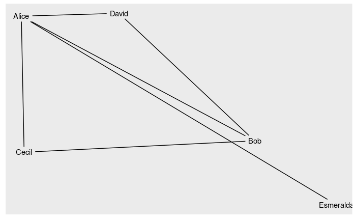

```r
t <- tbl_graph(nodes = actors, edges = relations, directed = TRUE, node_key = "name")

ggraph(t, layout = 'randomly') +
    geom_edge_link(aes(start_cap = label_rect(node1.name),
                       end_cap = label_rect(node2.name))) +
      geom_node_text(aes(label = name))
```

# Read plays

(Look at read-plays.Rmd for help)

```r
here()
```

```
[1] "/home/baj/Projects/P017_R_Project"
```

```r
#convert_TEI_to_JSONL(here("test-data"))
plays <- read_plays_jsonl(here("test-data"))
```

```
Advarsel i stream_in_int(path.expand(path)) : Parsing error on line 230
```

# Find Nodes (speakers)

We look at one play at a time.

```r
my_dir <-"test-data"
my_play <- "Hexerie_mod.jsonl"
read_play_jsonl(here(my_dir, my_play)) -> play
play #se den tbl, der nu er læst ind i play
```

| filename | act | act_number | docTitle | index | scene | scene_number | speaker | speaker_stage | spoke | stage | title | type | year |
| --- | --- | --- | --- | --- | --- | --- | --- | --- | --- | --- | --- | --- | --- |
| Hexerie_mod.jsonl | Første akt | 1 | Hekseri eller blind alarm Komedie i 5 akter | 1 | Scene 1 | 1 | Leander | NA | Der er farligt lidt at fortjene ved komedier nu om stunder. I denne måned har jeg ikke haft 20 rigsdaler på min part, det kan jeg gøre min ed på, så at jeg har aldrig været i sådan pengetrang som jeg … | NA | Hekseri eller blind alarm | 4 | (1731) |
| Hexerie_mod.jsonl | Første akt | 1 | Hekseri eller blind alarm Komedie i 5 akter | 2 | Scene 1 | 1 | Leander | NA | Jeg har en temmelig stærk rolle i samme tragedie. Thi Polidorus, hvis person jeg skal forestille, har mere at bestille end 3 andre aktører. Jeg kommer derfor at studere bravt både i dag og i morgen, o… | NA | Hekseri eller blind alarm | 4 | (1731) |
| Hexerie_mod.jsonl | Første akt | 1 | Hekseri eller blind alarm Komedie i 5 akter | 3 | Scene 1 | 1 | Leander | NA | NA | (Tager sit papir af lommen, hvormed han går frem og tilbage og læser over på sin rolle, først mumlende sagte) | Hekseri eller blind alarm | 2 | (1731) |
| Hexerie_mod.jsonl | Første akt | 1 | Hekseri eller blind alarm Komedie i 5 akter | 4 | Scene 1 | 1 | En dreng | (kommer ind) | NA | NA | Hekseri eller blind alarm | 3 | (1731) |
| Hexerie_mod.jsonl | Første akt | 1 | Hekseri eller blind alarm Komedie i 5 akter | 5 | Scene 1 | 1 | En dreng | NA | Monsieur, jeg har en ond tidende at sige jer. | NA | Hekseri eller blind alarm | 4 | (1731) |
| Hexerie_mod.jsonl | Første akt | 1 | Hekseri eller blind alarm Komedie i 5 akter | 6 | Scene 1 | 1 |  | NA | NA | ( Komedianten kontinuerer sin rolle højt) | Hekseri eller blind alarm | 2 | (1731) |
| Hexerie_mod.jsonl | Første akt | 1 | Hekseri eller blind alarm Komedie i 5 akter | 7 | Scene 1 | 1 |  | NA | Ja, Elisa, din utroskab skal aldrig blive uhævnet. Er det ret at forlade din tro Philander, der har reddet dig ved sit blod af de vanskabte kæmpers hænder, der har opofret sin velfærd, foragtet prinse… | NA | Hekseri eller blind alarm | 4 | (1731) |
| Hexerie_mod.jsonl | Første akt | 1 | Hekseri eller blind alarm Komedie i 5 akter | 8 | Scene 1 | 1 | NA | NA | NA | (Trækker sin kårde ud og vil tage livet af sig selv. Drengen mener det er alvor, løber til og holder ham i hånden) | Hekseri eller blind alarm | 1 | (1731) |
| Hexerie_mod.jsonl | Første akt | 1 | Hekseri eller blind alarm Komedie i 5 akter | 9 | Scene 1 | 1 | Leander | NA | Hvad pokker vil du her nu, dreng? Man kan aldrig et øjeblik have ro. | NA | Hekseri eller blind alarm | 4 | (1731) |
| Hexerie_mod.jsonl | Første akt | 1 | Hekseri eller blind alarm Komedie i 5 akter | 10 | Scene 1 | 1 | Drengen | NA | Hvad ulykke bringer jer til sådant fortvivlet forsæt at I vil tage livet af jer selv? | NA | Hekseri eller blind alarm | 4 | (1731) |

[output cut: 894 more lines]

```r
## Distinct speakers in each scene in each act grouped by act and scene
(play %>%
  filter(!is.na(speaker)) %>%
   filter(!(speaker == "")) %>%
  select(speaker, act_number, scene_number) %>%
     group_by(act_number, scene_number)  %>%
   distinct() -> distinct_speakers_play)
```

| speaker | act_number | scene_number |
| --- | --- | --- |
| Leander | 1 | 1 |
| En dreng | 1 | 1 |
| Drengen | 1 | 1 |
| Den fremmede person | 1 | 2 |
| Kællingen | 1 | 3 |
| Manden | 1 | 3 |
| Kællingen | 1 | 4 |
| Manden | 1 | 4 |
| 1. pige | 1 | 5 |
| 2. pige | 1 | 5 |

[output cut: 92 more lines]

```r
## Sammenlæg forskellige stavemåde af samme rolle
(distinct_speakers_play %>%
  # count all versions of Troels as one
  mutate(
    speaker = if_else(speaker %in% c("Troels", "Trols"), "Troels", speaker)) %>%
  # count all versions of Barselskvinden as one
  mutate(
    speaker = if_else(speaker %in% c("Barselskonen", "Barselskvinden", "Barselsqvinde"), "Barselskvinden", speaker)) %>%
  # Count all versions of kællingen as one
  mutate(
    speaker = if_else(speaker %in% c("Kælling", "Kællingen"), "Kællingen", speaker)) %>%
  # Count all versions of Pigen as one
  mutate(
    speaker = if_else(speaker %in% c("En pige", "Pigen"), "Pigen", speaker)) %>%
    # count all versions of Drengen as one
  mutate(
    speaker = if_else(speaker %in% c("Dreng", "Drengen", "En dreng"), "Drengen", speaker)) %>%
  distinct(speaker) -> distinct_speakers_play)
```

| speaker | act_number | scene_number |
| --- | --- | --- |
| Leander | 1 | 1 |
| Drengen | 1 | 1 |
| Den fremmede person | 1 | 2 |
| Kællingen | 1 | 3 |
| Manden | 1 | 3 |
| Kællingen | 1 | 4 |
| Manden | 1 | 4 |
| 1. pige | 1 | 5 |
| 2. pige | 1 | 5 |
| Manden | 1 | 5 |

[output cut: 91 more lines]

```r
## All distinct speakers in play are the nodes
(distinct_speakers_play %>%
    ungroup() %>%
    select(speaker) %>%
     distinct() %>%
   rowid_to_column("id") -> nodes_play) # add id column
```

| id | speaker |
| --- | --- |
| 1 | Leander |
| 2 | Drengen |
| 3 | Den fremmede person |
| 4 | Kællingen |
| 5 | Manden |
| 6 | 1. pige |
| 7 | 2. pige |
| 8 | Pigen |
| 9 | Henrik |
| 10 | Manden i portechaisen |

[output cut: 40 more lines]

```r
NA
```

# Find Edges

5. Find karakterer med replikker, der taler med hinanden – hele stykket.

```r
# we would like an edge-list like this
# edge_list <- tibble(from = c("Claus", "Corfitz", "Jeronimus"),
#                    to = c("Troels", "Troels", "Corfitz"))

## I.e. an edge for each pair of speakers in each scene in each act
## That is every combination of speakers within each group

#create column 'speaker2' and make it equal to 'speaker' (duplicate).
distinct_speakers_play$speaker2 = distinct_speakers_play$speaker
# All possible combinations (remember the data is still grouped by act-number and scene-number)
(distinct_speakers_play %>%
  expand(speaker, speaker2) -> who_speaks_to_whom)
```

| act_number | scene_number | speaker | speaker2 |
| --- | --- | --- | --- |
| 1 | 1 | Drengen | Drengen |
| 1 | 1 | Drengen | Leander |
| 1 | 1 | Leander | Drengen |
| 1 | 1 | Leander | Leander |
| 1 | 2 | Den fremmede person | Den fremmede person |
| 1 | 3 | Kællingen | Kællingen |
| 1 | 3 | Kællingen | Manden |
| 1 | 3 | Manden | Kællingen |
| 1 | 3 | Manden | Manden |
| 1 | 4 | Kællingen | Kællingen |

[output cut: 407 more lines]

```r
(who_speaks_to_whom  %>%
  ungroup() %>%
  select(from = speaker, to = speaker2) %>%
  distinct() -> edges_play)
```

| from | to |
| --- | --- |
| Drengen | Drengen |
| Drengen | Leander |
| Leander | Drengen |
| Leander | Leander |
| Den fremmede person | Den fremmede person |
| Kællingen | Kællingen |
| Kællingen | Manden |
| Manden | Kællingen |
| Manden | Manden |
| 1. pige | 1. pige |

[output cut: 302 more lines]

```r
NA
```

# Draw Graph

[figure not shown]

```r
# now we can draw a graph like this
gr <- tbl_graph(nodes = nodes_play, edges = edges_play, directed = TRUE, node_key = "speaker")


ggraph(gr, layout = 'kk') +
    geom_edge_link(aes(start_cap = label_rect(node1.speaker),
                       end_cap = label_rect(node2.speaker))) +
      geom_node_text(aes(label = speaker)) +
    labs(caption = paste("Netværksgraf", my_play))
```

# Graduer efter, hvor mange ord, de siger til hinanden.

Vi kan låne lidt fra “visualisering-ord-sagt.Rmd”

WORK IN PROGRESS

# TODO b. Talende karakter: det skal visuelt fremgå, dvs hvem der taler mest.

# TODO Nu kommer alt det spændende arbejde med at gøre grafen pæn :)

# TODO Til stede, men taler ikke, skal være kanter med en anden farve.

Vi kan også prøve at lave grafer for hver scene eller hver akt i stykket… # 6. Find karakterer, der taler med hinanden – opdelt i akt og scene.